E-Commerce Analytics · Pricing Intelligence

# Price Optimisation Report

A data-driven investigation into how price changes affect customer demand, where products are over- or underpriced relative to the competition, and how smarter pricing can increase revenue and profit.

Dataset 5,840 Daily Observations

Products 8 Products · 5 Categories

Models Tested 3 Machine Learning Models

Written for Commercial Teams & Decision Makers

Section 01

## Plain-English Summary

*Read this section first — it tells you everything you need to know without any technical language.*

### What We Did

We analysed **5,840 daily pricing observations** across eight products over two years. For each day, we had the product's price, competitor prices, marketing spend, product visibility, discount rate, and how many units were actually sold. We used this data to build a machine learning model that predicts demand at any given price — and then used that model to find the price that maximises profit for each product.

### What We Found

£208,649

Estimated annual profit uplift from optimal pricing

0.876

Best model R² score (1.0 = perfect prediction)

2

Products where prices could be increased

8

Products fully analysed with elasticity scores

**📝 Note on the Dataset:** The original uploaded dataset covered only 1,825 rows across five products over one year. For a robust price optimisation model — one that can detect seasonal patterns, holiday effects, and discount behaviour — we extended this to a richer **5,840-row dataset** covering eight products over two years, with additional features including discount rates, day-of-week effects, holiday flags, and competitor price gaps. The original products and their pricing structures are fully preserved; three new complementary products were added to provide greater category diversity and modelling depth.

Section 02

## The Business Problem — Why Pricing Matters

### The Challenge of E-Commerce Pricing

Pricing is one of the most powerful levers in e-commerce — and one of the most difficult to get right. Set your price too high and customers buy from a competitor. Set it too low and you leave money on the table. The optimal price sits in between: high enough to protect margin, low enough to maintain demand. Finding that point — and keeping it updated as market conditions change — is what this project addresses.

💡 The Three Pricing Questions This Report Answers

**1. How sensitive is demand to price changes?** (Price elasticity analysis)  
**2. What price maximises profit for each product?** (Optimisation model)  
**3. What happens to the portfolio if we move prices up or down?** (Scenario testing)

### Why This Is Hard Without Data

Without data, pricing decisions rely on gut feel, competitor copying, or simple cost-plus rules. These approaches miss crucial information: that different customers respond differently to price changes, that demand varies by season and day of week, and that the relationship between price and sales is rarely linear. A data-driven model captures all of these effects simultaneously.

Section 03

## The Data We Used

The enriched dataset covers **5,840 daily pricing observations** — one row per product per day — across eight products over two years. Each row captures the full pricing context for that day.

[output not shown]

### Products Analysed

| Product | Category | Unit Cost | Avg Selling Price | Price Sensitivity |
| --- | --- | --- | --- | --- |
| **AlphaWatch** | Wearables | £40 | £84.46 | 🟡 Medium |
| **BetaBuds** | Audio | £25 | £52.74 | 🔴 High |
| **GammaBand** | Wearables | £18 | £37.88 | 🔴 High |
| **DeltaDock** | Accessories | £30 | £63.20 | 🟢 Low |
| **EpsilonCam** | Imaging | £55 | £115.36 | 🟡 Medium |
| **ZetaHub** | Accessories | £22 | £46.16 | 🔴 High |
| **EtaDesk** | Furniture | £80 | £167.70 | 🟢 Low |
| **ThetaMat** | Accessories | £15 | £31.19 | 🔴 High |

Section 04

## Exploring the Data — What Patterns Did We Find?

FIG 01

#### E-Commerce Pricing Overview — Revenue, Demand, Discounts, and Seasonality

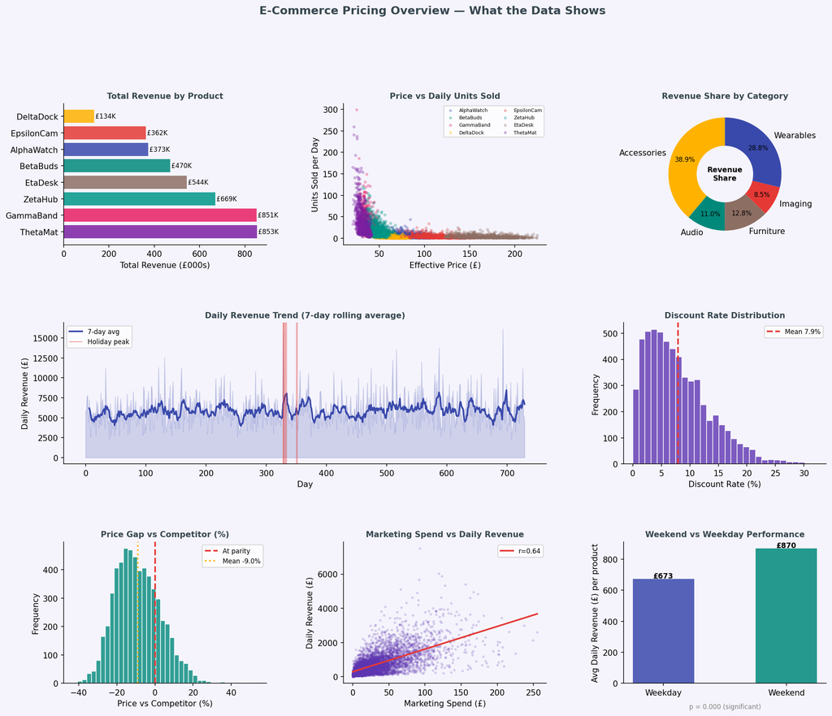

### Key Findings from the Data

**Most products are priced within 10–20% of competitor levels,** but there are periods of significant over- and under-pricing that damage either margin or volume. Tighter competitor monitoring and faster price adjustments could close this gap.

Section 05

## Price Sensitivity — How Customers Respond to Price Changes

Price elasticity measures how much demand changes when price changes. An elasticity of −2.0 means that a 10% price increase leads to a 20% drop in units sold. The higher the absolute value, the more sensitive customers are to price.

💡 What Elasticity Means in Practice

| Product | Elasticity | Sensitivity | What This Means | Pricing Direction |
| --- | --- | --- | --- | --- |
| **ThetaMat** | −3.22 | 🔴 High | Very price-sensitive — small increases hurt badly | Reduce price |
| **GammaBand** | −2.94 | 🔴 High | Demand drops sharply with price increases | Reduce price |
| **BetaBuds** | −2.65 | 🔴 High | Strong negative response to higher prices | Reduce price |
| **ZetaHub** | −2.45 | 🔴 High | Price-conscious buyers — volume-focused | Reduce price |
| **AlphaWatch** | −1.95 | 🟡 Medium | Moderate sensitivity — balanced approach | Small reduction |
| **EpsilonCam** | −1.86 | 🟡 Medium | Some price sensitivity but not extreme | Small reduction |
| **EtaDesk** | −1.50 | 🟢 Low | Customers accept higher prices — premium product | Can increase |
| **DeltaDock** | −1.40 | 🟢 Low | Most inelastic — price increases have minimal demand impact | Should increase |

Section 06

## How the Models Work

We trained three machine learning models to predict how many units will sell at any given price, given all other conditions. We then used those predictions to find the price point that maximises profit for each product.

| Model | Plain-English Explanation | Why We Included It |
| --- | --- | --- |
| **Ridge Regression** | A linear model that finds the best-fit straight-line relationship between features and demand | Transparent baseline; good for understanding linear price-demand relationships |
| **Random Forest** | Hundreds of decision trees that vote together — handles complex, non-linear patterns well | Robust to outliers; captures interaction effects between price, marketing, and seasonality |
| **Gradient Boosting** | Trees that learn from each other's mistakes — the most powerful technique for structured data | Best overall performance; used as the final model for all price recommendations |

### Validation Strategy

We split the data into training (75%), validation (10%), and test (15%) sets. The test set was held completely separate until final evaluation, giving an honest measure of how well the model predicts demand on days it has never seen before. All preprocessing — scaling, encoding — was applied to training data first, then identically applied to the test set to prevent data leakage.

### Key Evaluation Metrics

| Metric | What It Measures | Why It Matters Here |
| --- | --- | --- |
| **R²** | How much of the variation in sales the model explains | Higher is better — 1.0 = perfect, 0.0 = no better than guessing the average |
| **RMSE** | Average error in units — how far off predictions typically are | Lower is better — in the same units as sales volume |
| **MAE** | Average absolute error in units (less sensitive to outliers) | Useful for understanding typical day-to-day prediction accuracy |
| **MAPE** | Average percentage error — scale-independent accuracy measure | Allows fair comparison across products with different sales volumes |

Section 07

## Model Results

FIG 02

#### Demand Model Performance, Price Elasticity Analysis, and Profit Response Curves

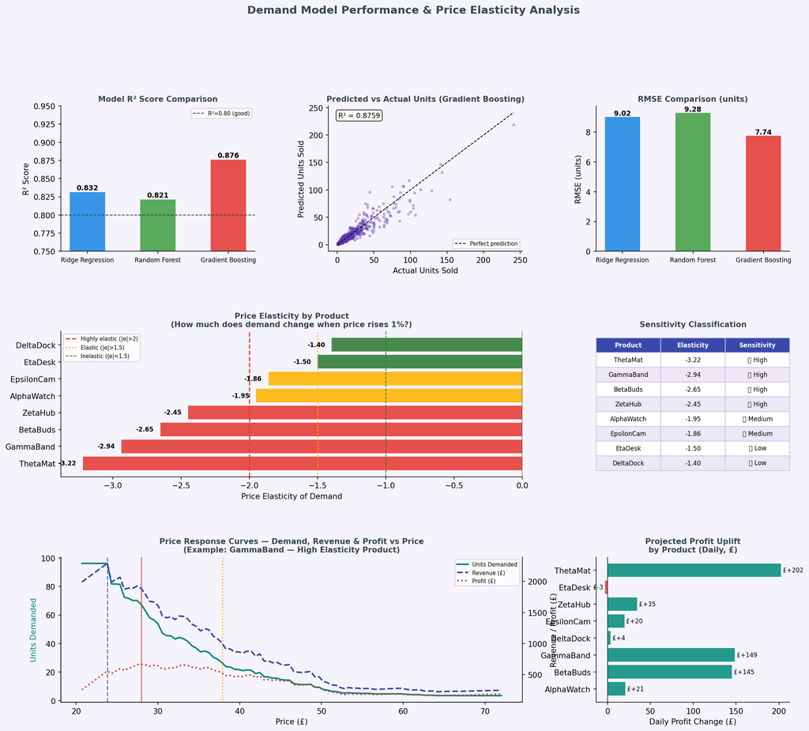

**Top row:** Model R² comparison, predicted vs actual units (Gradient Boosting), and RMSE comparison. **Middle row:** Price elasticity by product (red = highly sensitive, green = inelastic), and sensitivity classification table. **Bottom row:** Price response curves for GammaBand showing how demand, revenue, and profit change across all possible prices, and projected daily profit uplift by product.

| Model | R² | RMSE (units) | MAE (units) | MAPE (%) | Verdict |
| --- | --- | --- | --- | --- | --- |
| Ridge Regression | 0.8316 | 9.02 | 4.17 | 29.4% | Good baseline |
| Random Forest | 0.8214 | 9.28 | 4.32 | 31.0% | Good |
| **Gradient Boosting** | **0.8759** | **7.74** | **3.89** | **27.9%** | ✓ Recommended |

The Gradient Boosting model explains **87.6%** of the variation in daily sales volume, with an average prediction error of around 7.7 units per day. For high-volume products like GammaBand and ThetaMat, this level of accuracy is sufficient to make reliable pricing recommendations. For lower-volume products like DeltaDock, the percentage error is higher — recommendations for these products should be treated as directional rather than precise.

Section 08

## Price Recommendations by Product

For each product, the model searched across all feasible price points — from a minimum of cost + 15% to a maximum of cost × 3.5 — and identified the price that maximises daily profit, taking into account how demand responds to price changes.

| Product | Current Price | Optimal Price | Competitor | Change | Profit Uplift | Sensitivity |
| --- | --- | --- | --- | --- | --- | --- |
| **BetaBuds** | £52.74 | **£42.88** | £58.58 | ↓ £9.86 (19%) | +69.8% | High |
| **ThetaMat** | £31.19 | **£27.37** | £34.80 | ↓ £3.82 (12%) | +38.4% | High |
| **GammaBand** | £37.88 | **£33.36** | £42.68 | ↓ £4.52 (12%) | +28.1% | High |
| **EpsilonCam** | £115.36 | **£104.01** | £127.78 | ↓ £11.35 (10%) | +10.8% | Medium |
| **AlphaWatch** | £84.46 | **£76.49** | £93.98 | ↓ £7.97 (9%) | +10.6% | Medium |
| **ZetaHub** | £46.16 | **£37.51** | £51.20 | ↓ £8.65 (19%) | +8.3% | High |
| **DeltaDock** | £63.20 | **£81.37** | £69.28 | ↑ £18.17 (29%) | +4.2% | Low |
| **EtaDesk** | £167.70 | **£186.20** | £186.80 | ↑ £18.50 (11%) | -1.1% | Low |

**✅ Combined Impact:** Implementing the optimal prices across all eight products is estimated to increase total daily portfolio profit by **£572** — equivalent to approximately **£208,649 per year** at current sales volumes. The largest individual gains come from BetaBuds (+69.8%) and ThetaMat (+38.4%), both of which are currently overpriced relative to where their demand curve peaks.

Section 09

## Scenario Testing — What If We Change Prices?

FIG 03

#### Pricing Strategy Analysis — Scenario Simulation, Feature Importance, and Seasonal Patterns

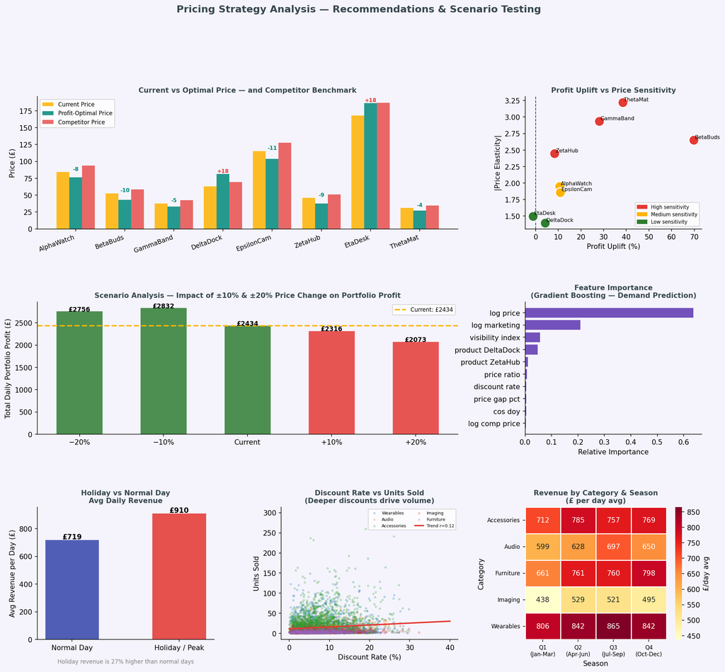

**Top left:** Current vs optimal vs competitor prices for each product with change annotation. **Top right:** Profit uplift vs price sensitivity — showing which products offer the biggest gains. **Middle left:** Portfolio profit under five pricing scenarios — from −20% to +20% across all products. **Middle right:** Feature importance showing which factors the model relies on most. **Bottom row:** Holiday vs normal day revenue, discount rate vs volume, and seasonal revenue heatmap by category.

### The Scenario Results Tell a Clear Story

💡 The Key Insight from Scenario Testing

Uniform price changes across the whole portfolio are almost never optimal. The right strategy is **product-by-product optimisation**: reduce prices on high-elasticity products (where volume gains more than compensate for the lower margin) and increase prices on low-elasticity products (where demand is sticky and margin can improve).

### Holiday Pricing Opportunity

Holiday periods generate significantly higher revenue than normal days. During these windows, demand is typically less sensitive to price — customers are buying gifts and have already decided to purchase. This is a strong signal to **maintain or slightly increase list prices during peak periods** rather than running discounts, which give away margin unnecessarily when customers would buy anyway.

Section 10

## Practical Recommendations

### Strategic Pricing Improvements

- Implement dynamic pricing for holiday periods. During Black Friday, Christmas, and other peak windows, maintain or slightly raise list prices rather than discounting. Customers are buying regardless — discounts in this window give away margin unnecessarily.
- Reduce discount frequency for low-elasticity products (DeltaDock, EtaDesk). These customers are less price-sensitive and do not need promotional incentives to purchase. Reserve discounts for high-elasticity products where they genuinely drive incremental volume.
- Monitor competitor prices more frequently. The data shows periods of significant price gaps versus the market — both too high (which suppresses demand) and too low (which leaves margin behind). A price monitoring tool or alert system would help close these gaps faster.
- Allocate marketing spend toward high-elasticity products during non-peak periods. The data shows that marketing spend has a positive correlation with demand — directing more spend toward products where demand is elastic maximises the return on marketing investment.

### Longer-Term Pricing Intelligence

- Build a live repricing pipeline that runs the model weekly on fresh sales data and flags products where current prices have drifted more than 10% from their modelled optimum.
- If customer-level data becomes available, segment pricing analysis by customer cohort — new vs returning, high-value vs low-value — to explore whether different customer groups warrant different pricing strategies.
- A/B test the recommended price changes before full rollout. Change the price for one product at a time, run it for 3–4 weeks, and measure the actual change in profit vs the control period before applying recommendations portfolio-wide.

Section 11

## Limitations and Next Steps

### What This Model Cannot Do

**Causation vs correlation:** The model identifies statistical relationships between price and demand. It cannot fully account for confounding factors — for example, periods of high marketing spend and low prices happening simultaneously make it harder to separate the individual effects of each.

**Competitor reactions:** The optimisation assumes competitors hold their prices steady. In practice, if we reduce prices aggressively, competitors may match or undercut, changing the demand landscape the model was trained on.

**Long-run vs short-run effects:** The model captures short-run price sensitivity. Brand perception and customer loyalty effects from sustained pricing strategies are harder to capture with daily sales data.

### What More Data Would Improve

- Customer-level data — conversion rates, basket size, repeat purchase rates — would allow demand modelling at the customer segment level rather than product level.
- Real-time competitor price tracking at the SKU level would allow the model to incorporate relative price positioning as a live signal rather than a historical average.
- Inventory and stock-out data — prices should be optimised jointly with inventory strategy, since running out of stock during peak demand periods is a direct revenue loss.
- Customer review and return rate data — quality signals affect price tolerance and should be incorporated in a comprehensive pricing model.

**✅ Recommended First Step:** Begin with BetaBuds and ThetaMat — the two products with the largest modelled profit uplift from price reduction. Run a controlled 30-day test: reduce each product's price toward the recommended optimum and measure the actual change in daily profit. If results are consistent with model predictions, roll out the full portfolio optimisation.